# La correlación entre las inmigraciones y los índices de violencia en México

Inmigraciones vs Violencia

Ponce Sanchez, Max Albert  
Strater Mc Lellan, Luis Eduardo  
Puchuri Orellano, Piero Marcelo  
Cárdenas Aguirre, Sebastian Edgard  
Anticona Puza, Francescolli Gustavo(Líder de grupo)  
Profesor: Rojas Melasquez, Royer Edelwer

20/05/2020

# **Condiciones para la regresión lineal**

1. **Linealidad**: La relación entre el predictor y la variable respuesta ha de ser lineal. ¿Cómo comprobarlo? Diagrama de dispersión de los datos, **graficar los residuos**.
2. **Distribución normal de los residuos**: los residuos deben distribuirse de forma normal, en torno a 0. Esta condición podría no cumplirse en presencia de observaciones atípicas o outliers que no siguen el patrón del conjunto de datos. ¿Cómo comprobarlo? Histograma de los datos, distribución de quantiles (normal Q-Q plot), test de **hipótesis de normalidad**.

# **Analisis exploratorio - Migración vs Percepción de Seguridad**

Antes de generar el modelo, representaremos los datos para cuantificar la posible relación lineal entre variables y su magnitud. Si no detectáramos esta relación pasaríamos a plantearnos métodos de ajuste alternativos.

# **Analisis exploratorio - Migración vs Percepción de Seguridad**

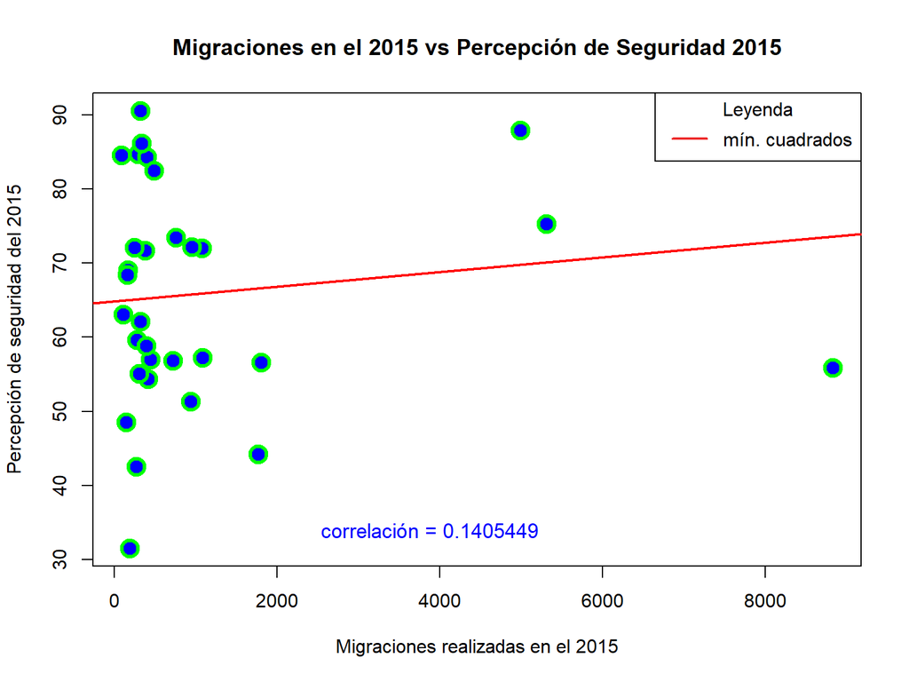

# **Analisis exploratorio - Migración vs Percepción de Seguridad**

```
##
##  Pearson's product-moment correlation
##
## data:  Nueva_tabla_2$I_2015 and a$`2015`
## t = 0.77751, df = 30, p-value = 0.4429
## alternative hypothesis: true correlation is not equal to 0
## 90 percent confidence interval:
##  -0.1625066  0.4193665
## sample estimates:
##       cor
## 0.1405449
```

# **Analisis exploratorio - Migración vs Percepción de Seguridad**

De lo hasta ahora analizado podemos concluir que:

- Observando los gráficos de dispersión podemos observar que la variable Migraciones en el 2015 no está asociada con la variable de Percepción de seguridad Pública del 2015.

$$H_0: \rho=0$$

$$H_1:\rho\neq0$$
$$P-value\leq \alpha$$

- Si esta condición se cumple, se rechaza la hipótesis nula
- En caso contrario no se rechaza.

# **Analisis exploratorio - Migración vs Percepción de Seguridad**

- El coeficiente de correlación de Pearson es bastante bajo (r = 0.1405449) y poco significativo (p-value = 0.4429), entonces no se rechaza la hipótesis nula. Esto nos indica una correlación entre ambas variables bastante baja.
- No tiene sentido generar el modelo de regresión lineal cumpliéndose estos primeros requisitos.

# **Analisis exploratorio - Migración vs Percepción de Seguridad**

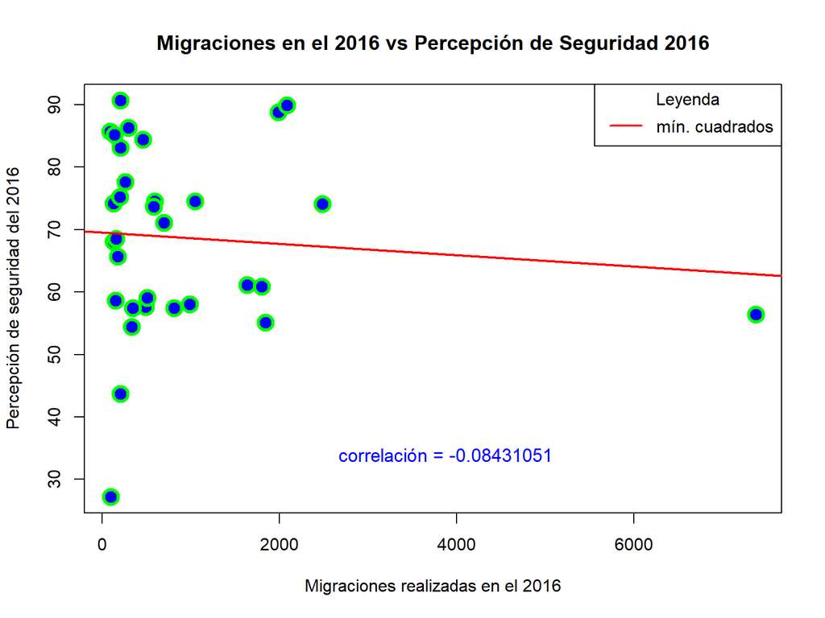

# **Analisis exploratorio - Migración vs Percepción de Seguridad**

```
##
##  Pearson's product-moment correlation
##
## data:  Nueva_tabla_2$I_2016 and a$`2016`
## t = -0.46344, df = 30, p-value = 0.6464
## alternative hypothesis: true correlation is not equal to 0
## 90 percent confidence interval:
##  -0.3713195  0.2174048
## sample estimates:
##         cor
## -0.08431051
```

# **Analisis exploratorio - Migración vs Percepción de Seguridad**

De lo hasta ahora analizado podemos concluir que:

- Observando los gráficos de dispersión podemos observar que la variable Migraciones en el 2016 no está asociada con la variable de Percepción de seguridad Pública del 2016.

$$H_0: \rho=0$$

$$H_1:\rho\neq0$$
$$P-value\leq \alpha$$

- Si esta condición se cumple, se rechaza la hipótesis nula.
- En caso contrario no se rechaza.

# **Analisis exploratorio - Migración vs Percepción de Seguridad**

- El coeficiente de correlación de Pearson es bastante bajo (r = -0.08431051) y poco significativo (p-value = 0.6464), entonces no se rechaza la hipótesis nula. Esto nos indica una correlación entre ambas variables bastante baja.
- No tiene sentido generar el modelo de regresión lineal cumpliéndose estos primeros requisitos.

# **Analisis exploratorio - Migración vs Percepción de Seguridad**

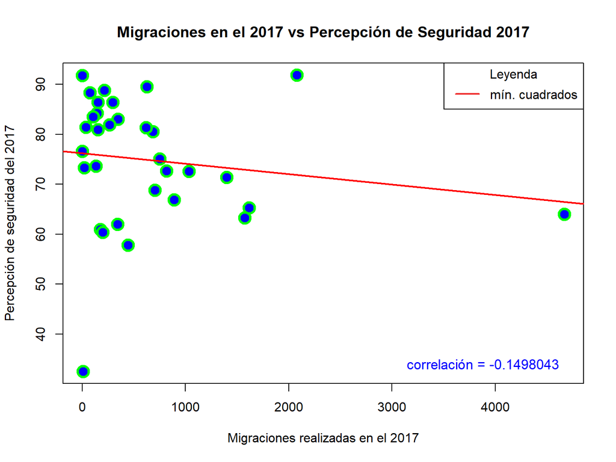

## **Analisis exploratorio - Migración vs Percepción de Seguridad**

```
##
##  Pearson's product-moment correlation
##
## data:  Nueva_tabla_2$I_2017 and a$`2017`
## t = -0.82988, df = 30, p-value = 0.4132
## alternative hypothesis: true correlation is not equal to 0
## 90 percent confidence interval:
##  -0.4271308  0.1532837
## sample estimates:
##        cor
## -0.1498043
```

# **Analisis exploratorio - Migración vs Percepción de Seguridad**

De lo hasta ahora analizado podemos concluir que:

- Observando los gráficos de dispersión podemos observar que la variable Migraciones en el 2017 no está asociada con la variable de Percepción de seguridad Pública del 2017.

$$H_0: \rho=0$$

$$H_1:\rho\neq0$$
$$P-value\leq \alpha$$

- Si esta condición se cumple, se rechaza la hipótesis nula.
- En caso contrario no se rechaza.

# **Analisis exploratorio - Migración vs Percepción de Seguridad**

- El coeficiente de correlación de Pearson es bastante bajo (r = -0.1498043) y poco significativo (p-value = 0.4132), entonces no se rechaza la hipótesis nula. Esto nos indica una correlación entre ambas variables bastante baja.
- No tiene sentido generar el modelo de regresión lineal cumpliéndose estos primeros requisitos.

# **Analisis exploratorio - Migración vs Percepción de Seguridad**

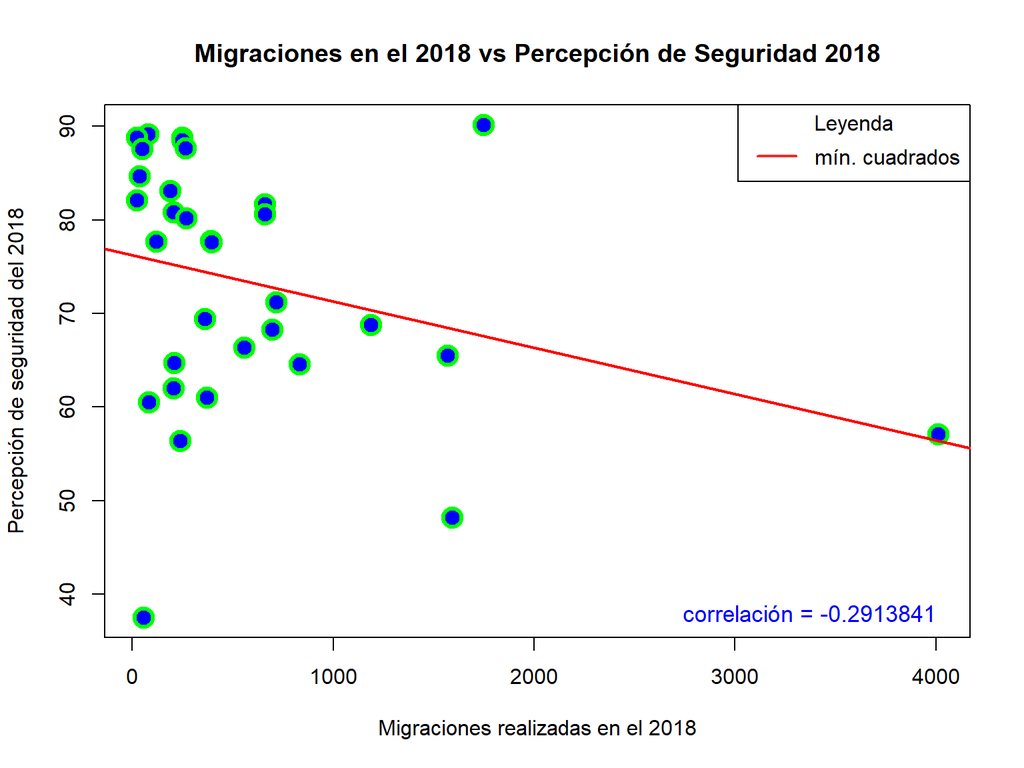

# **Analisis exploratorio - Migración vs Percepción de Seguridad**

```
##
##  Pearson's product-moment correlation
##
## data:  Nueva_tabla_2$I_2018 and a$`2018`
## t = -1.6684, df = 30, p-value = 0.1056
## alternative hypothesis: true correlation is not equal to 0
## 90 percent confidence interval:
##  -0.540965660  0.005363485
## sample estimates:
##        cor
## -0.2913841
```

# **Analisis exploratorio - Migración vs Percepción de Seguridad**

De lo hasta ahora analizado podemos concluir que:

- Observando los gráficos de dispersión podemos observar que la variable Migraciones en el 2018 está ligeramente asociada con la variable de Percepción de seguridad Pública del 2018.

$$H_0: \rho=0$$

$$H_1:\rho\neq0$$
$$P-value\leq \alpha$$

- Si esta condición se cumple, se rechaza la hipótesis nula.
- En caso contrario no se rechaza.

# **Analisis exploratorio - Migración vs Percepción de Seguridad**

- El coeficiente de correlación de Pearson es bastante bajo (r = -0.2913841) y poco significativo (p-value = 0.1056), entonces no se rechaza la hipótesis nula. Esto nos indica una correlación entre ambas variables bastante baja.
- No tiene sentido generar el modelo de regresión lineal cumpliéndose estos primeros requisitos.

# **Conclusiones - Migración vs Percepción de Seguridad**

- En los cuatro casos no se cumplen las condiciones iniciales para poder realizar la regresión lineal. En el caso del ánalisis del 2018 la correlación fue un poco más alta, pero al realizar la prueba de hipótesis nos dimos cuenta que no tenía sentido realizar la regreción lineal.
- Aparentemente no habría relación entre la Migración y Percepción de Seguridad.

# **Analisis exploratorio - Inmigrantes Irregulares vs Tasa de Incidencia Delictiva**

[figure not shown]

# **Analisis exploratorio - Inmigrantes Irregulares vs Tasa de Incidencia Delictiva**

```
##
##  Pearson's product-moment correlation
##
## data:  irregul$Total and tasa_incidencia$`2019`
## t = -1.7202, df = 30, p-value = 0.0957
## alternative hypothesis: true correlation is not equal to 0
## 95 percent confidence interval:
##  -0.5869996  0.0547815
## sample estimates:
##        cor
## -0.2996361
```

# **Analisis exploratorio - Inmigrantes Irregulares vs Tasa de Incidencia Delictiva**

De lo hasta ahora analizado podemos concluir que:

- Observando los gráficos de dispersión podemos observar que la variable Inmigrantes Irregulares en el 2019 está ligeramente asociada con la variable de Incidencia Delictiva en el 2019.

$$H_0: \rho=0$$

$$H_1:\rho\neq0$$
$$P-value\leq \alpha$$

- Si esta condición se cumple, se rechaza la hipótesis nula.
- En caso contrario no se rechaza.

# **Analisis exploratorio - Inmigrantes Irregulares vs Tasa de Incidencia Delictiva**

# **Analisis exploratorio - Inmigrantes Irregulares vs Tasa de Incidencia Delictiva**

De hacer una regresión lineal los resultados serían los siguiente.

```
##
## Call:
## lm(formula = tasa_incidencia$`2019` ~ irregul$Total)
##
## Residuals:
##    Min     1Q Median     3Q    Max
## -12863  -7187  -1042   5112  32056
##
## Coefficients:
##                 Estimate Std. Error t value Pr(>|t|)
## (Intercept)   30635.6865  2068.2600   14.81 2.45e-15 ***
## irregul$Total    -0.2320     0.1349   -1.72   0.0957 .
## ---
## Signif. codes:  0 '***' 0.001 '**' 0.01 '*' 0.05 '.' 0.1 ' ' 1
##
## Residual standard error: 10860 on 30 degrees of freedom
## Multiple R-squared:  0.08978,    Adjusted R-squared:  0.05944
## F-statistic: 2.959 on 1 and 30 DF,  p-value: 0.0957
```

# **Analisis exploratorio - Inmigrantes Irregulares vs Tasa de Incidencia Delictiva**

$$H_0: \beta=0$$

$$H_1:\beta\neq0$$
$$P-value\leq \alpha$$

# **Analisis exploratorio - Inmigrantes Irregulares vs Tasa de Incidencia Delictiva**

- Antes de intentar hacer estimaciones se debe validar el modelo por lo que harémos un análisis de residuos.

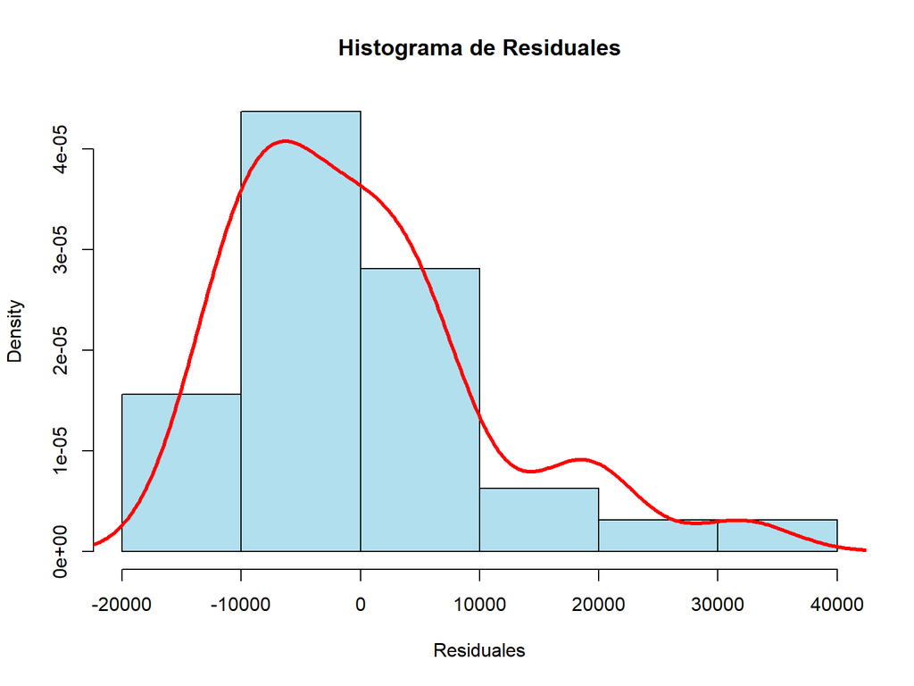

## **Analisis exploratorio - Inmigrantes Irregulares vs Tasa de Incidencia Delictiva**

Claramente se puede observar que los residuos no siguen una distribución normal por lo que el modelo no es válido y no sería correcto hacer estimaciones.

# **Analisis exploratorio - Cantidad de Deportados vs Percepción de Seguridad Pública**

[figure not shown]

# **Analisis exploratorio - Cantidad de Deportados vs Percepción de Seguridad Pública**

```
##
##  Pearson's product-moment correlation
##
## data:  irregul$`Cantidad de deportados 2019` and seguridad_2019
## t = -0.16316, df = 30, p-value = 0.8715
## alternative hypothesis: true correlation is not equal to 0
## 95 percent confidence interval:
##  -0.3745808  0.3222640
## sample estimates:
##         cor
## -0.02977595
```

# **Analisis exploratorio - Cantidad de Deportados vs Percepción de Seguridad Pública**

De lo hasta ahora analizado podemos concluir que:

- Observando los gráficos de dispersión podemos observar que la variable Cantidad de Deportados en el 2019 no está asociada con la variable de Percepción de seguridad Pública del 2019.

$$H_0: \rho=0$$

$$H_1:\rho\neq0$$
$$P-value\leq \alpha$$

- Si esta condición se cumple, se rechaza la hipótesis nula.
- En caso contrario no se rechaza.

# **Analisis exploratorio - Cantidad de Deportados vs Percepción de Seguridad Pública**

- El coeficiente de correlación de Pearson es casi nulo (r = -0.02977595) y poco significativo (p-value = 0.8715), entonces se no rechaza la hipótesis nula. Esto nos indica una correlación casi nula entre ambas variables.
- No tiene sentido generar el modelo de regresión lineal cumpliéndose estos primeros requisitos.

# **Analisis exploratorio - Cantidad de Deportados vs Tasa de Incidencia Delictiva**

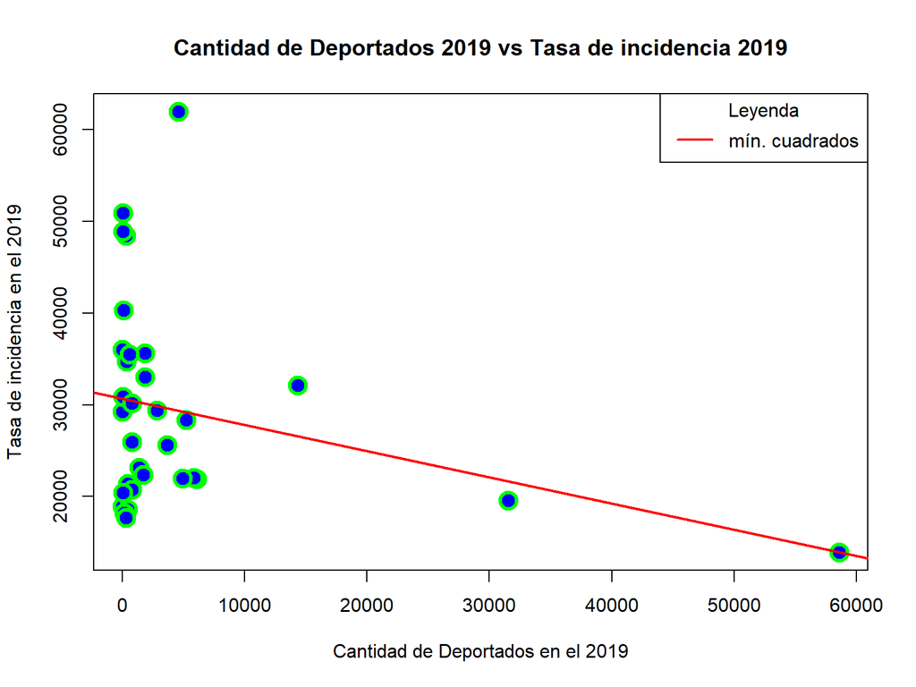

# **Analisis exploratorio - Cantidad de Deportados vs Tasa de Incidencia Delictiva**

```
##
##  Pearson's product-moment correlation
##
## data:  irregul$`Cantidad de deportados 2019` and tasa_incidencia$`2019`
## t = -1.6812, df = 30, p-value = 0.1031
## alternative hypothesis: true correlation is not equal to 0
## 95 percent confidence interval:
##  -0.58251981  0.06156609
## sample estimates:
##        cor
## -0.2934271
```

# **Analisis exploratorio - Cantidad de Deportados vs Tasa de Incidencia Delictiva**

De lo hasta ahora analizado podemos concluir que:

$$H_0: \rho=0$$

$$H_1:\rho\neq0$$
$$P-value\leq \alpha$$

- Si esta condición se cumple, se rechaza la hipótesis nula.
- En caso contrario no se rechaza.

# **Analisis exploratorio - Cantidad de Deportados vs Tasa de Incidencia Delictiva**

- El coeficiente de correlación de Pearson es bastante bajo (r = -0.2934271) y poco significativo (p-value = 0.1031), no se rechaza la hipótesis nula. Esto nos indica una correlación entre ambas variables bastante baja.
- No tiene sentido generar el modelo de regresión lineal cumpliéndose estos primeros requisitos.

# **Reflexiones y Conclusiones**

- **Conclusiones**:
- **¿Qué relación existe entre el índice de violencia y el de inmigraciones?**
  - En base a lo que hemos analizado no hay una aparente relación entre las inmigraciones y el índice de violencia. Sin embargo, en las primeras entregas encontramos que si había un ligero rechazo.
- Fundamentación
- **¿En qué región se presenta mayor índice de violencia en el caso de inmigración?**
  - En la busqueda de bases de datos que nos den relación entre la violecia y las inmigraciones se observó que las preguntas relacionadas a temas de violencia siempre eran negativas por lo que aparentemente no existia una relación entre dichas variables.
- Fundamentación

# **Reflexiones y Conclusiones**

- **¿Se percibe inseguridad/incomodidad en presencia de un inmigrante?**
  - Las bases de datos que corresponden a temas de violencia no parecen demostrar la verdadera situación que se vive en las fronteras.
- Fundamentación
- **¿Cuales son los motivos más frecuentes por los que se presenta discriminación?**
  - En general la presencia de un inmigrante representa inseguridad y un temor a la perdida de trabajo.
- Fundamentación

# **Reflexiones y Conclusiones**

# **Reflexiones y Conclusiones**